# ADAM M. SLOCINSKI, B.A. (Hons), M.Sc.*

## SUMMARY OF SKILLS

- **Research and Analysis**:

  Extensive experience gathering, analyzing, and synthesizing quantitative and qualitative data from diverse sources while leveraging research methodologies to provide actionable recommendations to clients and decision-makers.
- **Initiative and Solution Engineering**:

  Skilled at planning, monitoring, interpreting complex information, identifying options, and presenting recommendations in multi-stakeholder projects.
- **Digital and Data Savvy**:

  Practical and graduate-level experience leveraging data to support executive-level briefings and advance projects in fast-paced, multidisciplinary environments.
- **Teamwork and Leadership**:

  Thrives in agile, client-centric settings as an active contributor, critical technical and morale-boosting team member, and leader.
- **Growth Mindset**:

  Embraces challenges, persists through setbacks, and orients feedback to continually improve and learn as an analyst.

## RELEVANT WORK EXPERIENCE

**Analyst,** **HR Analytics and Intelligence,** **Treasury Board of Canada Secretariat**

May 2022 — CURRENT  
[Ottawa, Canada](https://www.openstreetmap.org/?mlat=45.4215&mlon=-75.6972#map=12/45.4215/-75.6972)

Principal report developer

- Contributes across all project stages, from research to data product publishing
- Leverages Python and Web coding skills to support data-driven decision-making
- Self-starter and leader in troubleshooting the implementation of a business intelligence reporting framework that improves data quality and accuracy
- Passionately and proactively troubleshoots code, dashboard files, and processes to lighten administrative loads
- Develops and maintains documentation and learning resources for junior-level team members
- Ensures accessibility and official language compliance for Power BI reports
- Develops and maintains partnerships with key stakeholders and clients across different business lines

**Advisor,** **Workplace Wellness and Employee Engagement,** **Treasury Board of Canada Secretariat**

May 2021 — April 2022  
[Ottawa, Canada](https://www.openstreetmap.org/?mlat=45.4215&mlon=-75.6972#map=12/45.4215/-75.6972)

Champions accessibility

- Created accessible documents in official languages using specialized software
- Showed passion for continuous learning with a keen interest for expanding tech skills
- Performed exploratory data analysis on employee survey results to inform evidence-based decisions
- Produced data visualizations, speaking notes, briefing and presentational materials for executives
- Researched and reviewed occupational health and safety information to update intranet content
- Managed generic mailboxes and scheduled employee-level and executive-level working group meetings

**Student,** **Data Development and Partnerships,** **Agriculture and Agri-Food Canada**

May 2020 — April 2021  
[Ottawa, Canada](https://www.openstreetmap.org/?mlat=45.4215&mlon=-75.6972#map=12/45.4215/-75.6972)

- Developed a high-level communications strategy proposal for the incoming Chief Data Officer
- Edited and verified language and data in written communications for internal distribution
- Recreated data visualizations in Power BI for a monthly reporting initiative
- Researched and briefed the team on data literacy models and open data policy trends

**Research Assistant,** **Jean-Léon Allie Library and Archives,** **Saint Paul University**

March 2020 — March 2021  
[Ottawa, Canada](https://www.openstreetmap.org/?mlat=45.4215&mlon=-75.6972#map=12/45.4215/-75.6972)

Research-oriented

- Performed an environmental scan on over 100 Canadian university library websites
- Conducted a literature review to identify trends in research data management
- Prepared a comparative analysis to support recommendations for new library research aids
- Organized and classified indigenous collection materials for inclusion in the library database
- Digitized materials by scanning, sorting, annotating, and preparing them for retrieval

## EDUCATION

**Master of Science,** **Computer and Systems Sciences (Open eGovernment programme),** **Stockholm University**

August 2023 — June 2025  
[Stockholm, Sweden](https://www.openstreetmap.org/?mlat=59.3293&mlon=18.0686#map=12/59.3293/18.0686)

- Thesis: *“Fairness-aware machine learning for superdiversity”*

**Honours Bachelor of Arts,** **Conflict Studies (Sociology programme),** **University of Ottawa & Saint Paul University**

May 2018 — December 2021  
[Ottawa, Canada](https://www.openstreetmap.org/?mlat=45.4215&mlon=-75.6972#map=12/45.4215/-75.6972)

Political science and digital government background

- Research assistantship contracts completed in Summer 2020 and Winter 2021
- Research internship completed at Jean-Léon Allie Library and Archives in Fall 2020

## AWARDS AND RECOGNITION

**2024-2025 TBS Talent Mobility Tool**

July 2024

- Included in the 2024-2025 TBS Talent Mobility Tool and placed as ready for advancement, second year in a row

**TBS Employee Recognition Award**

June 2024

- Received recognition for my role in supporting the human resources information management system transition to MyGCHR

**Magna cum laude distinction**

June 2022

- Received *magna cum laude* distinction on honours bachelor degree

## LANGUAGES

Culturally adept

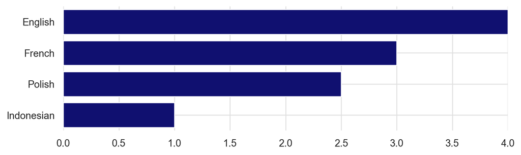

Figure 1: Languages sorted by proficiency, highest to lowest